# hw_house_price_india

DataSloth

2023-08-15

# version: nb

# This project will predict the price of Indian house using linear regression by R Programming

Source : data.world  
type of source: xlsx

## Start with load library

```r
#load library
library(tidyverse)
library(caret)
library(mlbench)
library(readxl)
library(ggplot2)
```

## Load data file to dataframe(“df1 = sheet1, df2 = sheet2”)

```r
# Load data
df1<-read_excel("hpi.xlsx", sheet = 1)
df2<-read_excel("hpi.xlsx", sheet = 2)
```

## Visualized data(df1) ~ Price

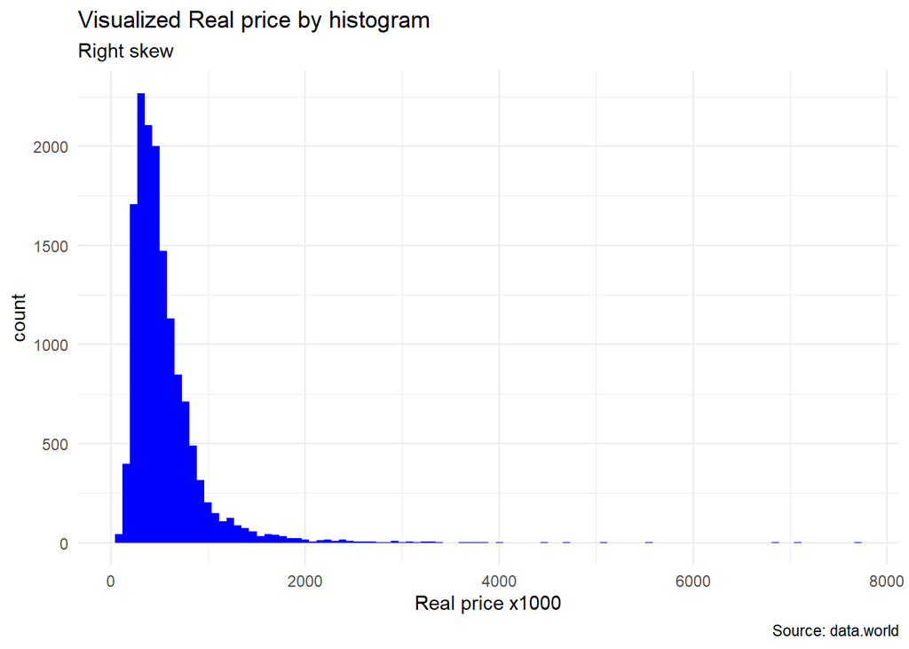

```r
ggplot(df1, aes(Price/1000)) +
  geom_histogram(bins = 100, fill="blue") +
  theme_minimal() +
  labs(
    title = "Visualized Real price by histogram",
    subtitle = "Right skew",
    x = "Real price x1000",
    caption = "Source: data.world"
  )
```

Note: Right skew distribution, not proper for build model but try it.

### Create function split_data

```r
split_data <- function(df) {
  set.seed(42)
  n <- nrow(df)
  id <- sample(1:n, size = 0.8*n)
  train_df <- df[id, ]
  test_df <- df[-id, ]
  list(train_df, test_df)
}
```

## 1.Use full data and real price to build model

### 1.1 Split full df1 and real price

```r
prep_data <- split_data(df1)
train_data <- prep_data[[1]]
test_data <- prep_data[[2]]
```

### 1.2 Train model full df1 and real price

### 1.2.1 Train

```r
model <- train(Price ~ .,
               data = train_data[ ,-c(1,2)], #remove id and date
               method = "lm")
```

### 1.2.2 Show model and summary model

```r
model ; summary(model)
```

```
## Linear Regression
##
## 11696 samples
##    20 predictor
##
## No pre-processing
## Resampling: Bootstrapped (25 reps)
## Summary of sample sizes: 11696, 11696, 11696, 11696, 11696, 11696, ...
## Resampling results:
##
##   RMSE      Rsquared  MAE
##   192549.8  0.711037  123219.8
##
## Tuning parameter 'intercept' was held constant at a value of TRUE
```

```
##
## Call:
## lm(formula = .outcome ~ ., data = dat)
##
## Residuals:
##      Min       1Q   Median       3Q      Max
## -1111112   -96339    -8097    75756  3896879
##
## Coefficients: (1 not defined because of singularities)
##                                                 Estimate Std. Error t value
## (Intercept)                                   -6.807e+07  1.241e+07  -5.485
## `\\`number of bedrooms\\``                    -3.545e+04  2.577e+03 -13.759
## `\\`number of bathrooms\\``                    4.235e+04  4.250e+03   9.966
## `\\`living area\\``                            1.409e+02  5.716e+00  24.652
## `\\`lot area\\``                              -5.479e-03  6.445e-02  -0.085
## `\\`number of floors\\``                       6.220e+03  4.677e+03   1.330
## `\\`waterfront present\\``                     6.331e+05  2.217e+04  28.558
## `\\`number of views\\``                        4.595e+04  2.800e+03  16.408
## `\\`condition of the house\\``                 3.138e+04  2.994e+03  10.479
## `\\`grade of the house\\``                     1.003e+05  2.814e+03  35.648
## `\\`Area of the house(excluding basement)\\``  3.560e+01  5.671e+00   6.278
## `\\`Area of the basement\\``                          NA         NA      NA
## `\\`Built Year\\``                            -2.509e+03  9.334e+01 -26.879
## `\\`Renovation Year\\``                        2.295e+01  4.574e+00   5.016
## `\\`Postal Code\\``                            2.610e+02  1.006e+02   2.596
## Lattitude                                      5.509e+05  1.429e+04  38.557
## Longitude                                     -9.900e+04  1.566e+04  -6.323
## living_area_renov                              2.529e+01  4.512e+00   5.606
## lot_area_renov                                -3.178e-01  9.726e-02  -3.268
## `\\`Number of schools nearby\\``               3.513e+03  2.178e+03   1.613
## `\\`Distance from the airport\\``              1.344e+01  1.993e+02   0.067
##                                               Pr(>|t|)
## (Intercept)                                   4.22e-08 ***
## `\\`number of bedrooms\\``                     < 2e-16 ***
## `\\`number of bathrooms\\``                    < 2e-16 ***
## `\\`living area\\``                            < 2e-16 ***
## `\\`lot area\\``                               0.93226
## `\\`number of floors\\``                       0.18359
## `\\`waterfront present\\``                     < 2e-16 ***
## `\\`number of views\\``                        < 2e-16 ***
## `\\`condition of the house\\``                 < 2e-16 ***
## `\\`grade of the house\\``                     < 2e-16 ***
## `\\`Area of the house(excluding basement)\\`` 3.56e-10 ***
## `\\`Area of the basement\\``                        NA
## `\\`Built Year\\``                             < 2e-16 ***
## `\\`Renovation Year\\``                       5.34e-07 ***
## `\\`Postal Code\\``                            0.00946 **
## Lattitude                                      < 2e-16 ***
## Longitude                                     2.67e-10 ***
## living_area_renov                             2.12e-08 ***
## lot_area_renov                                 0.00109 **
## `\\`Number of schools nearby\\``               0.10684
## `\\`Distance from the airport\\``              0.94624
## ---
## Signif. codes:  0 '***' 0.001 '**' 0.01 '*' 0.05 '.' 0.1 ' ' 1
##
## Residual standard error: 192300 on 11676 degrees of freedom
## Multiple R-squared:  0.7136, Adjusted R-squared:  0.7131
## F-statistic:  1531 on 19 and 11676 DF,  p-value: < 2.2e-16
```

### 1.3 score~predict model

```r
p <- predict(model, newdata = test_data)
```

### 1.4 Evaluate model

#### Create function to calculate MAE, MSE, RMSE

#### Create function to show error of model and save result to list, note: error in real price and logarithm price

```r
cal_mae <- function(actual, predict) {
  error <- actual - predict
  mean(abs(error))
}

cal_mse <- function(actual, predict) {
  error <- actual - predict
  mean(error**2)
}

cal_rmse <- function(actual, predict) {
  error <- actual - predict
  sqrt(mean(error**2))
}

r_train <- function(A,P,M = model) {
  mae_log <- cal_mae(A$log_price, P)
  mse_log <- cal_mse(A$log_price, P)
  rmse_log <- cal_rmse(A$log_price, P)
  mae_expo <- cal_mae(exp(A$log_price), exp(P))
  mse_expo <- cal_mse(exp(A$log_price), exp(P))
  rmse_expo <- cal_rmse(exp(A$log_price), exp(P))
  print("--Evaulation of TRAIN--");
  print(paste("MAE_log_train : ",mae_log)) ;
  print(paste("MSE_log_train : ",mse_log)) ;
  print(paste("RMSE_log_train : ",rmse_log)) ;
  print(paste("MAE_expo_train : ",mae_expo)) ;
  print(paste("MSE_expo_train : ",mse_expo)) ;
  print(paste("RMSE_expo_train : ",rmse_expo)) ;
  print(paste("MAE_model : "  ,      M[[4]][[4]])) ;
  print(paste("Rsquared_model : "  , M[[4]][[3]])) ;
  print(paste("RMSE_model : " ,      M[[4]][[2]])) ;
  list(mae_log, mse_log, rmse_log, mae_expo, mse_expo, rmse_expo)
}

r_test <- function(A,P,M = model) {
  mae_log <- cal_mae(A$log_price, P)
  mse_log <- cal_mse(A$log_price, P)
  rmse_log <- cal_rmse(A$log_price, P)
  mae_expo <- cal_mae(exp(A$log_price), exp(P))
  mse_expo <- cal_mse(exp(A$log_price), exp(P))
  rmse_expo <- cal_rmse(exp(A$log_price), exp(P))
  print("--Evaulation of TEST--");
  print(paste("MAE_log_test : ",mae_log)) ;
  print(paste("MSE_log_test : ",mse_log)) ;
  print(paste("RMSE_log_test : ",rmse_log)) ;
  print(paste("MAE_expo_test : ",mae_expo)) ;
  print(paste("MSE_expo_test : ",mse_expo)) ;
  print(paste("RMSE_expo_test : ",rmse_expo)) ;
  print(paste("MAE_model : "  ,      M[[4]][[4]])) ;
  print(paste("Rsquared_model : "  , M[[4]][[3]])) ;
  print(paste("RMSE_model : " ,      M[[4]][[2]])) ;
  list(mae_log, mse_log, rmse_log, mae_expo, mse_expo, rmse_expo)
}
```

### 1.5 Show error of model full df1 and real price

```r
print(paste("MAE_test : "  , cal_mae(test_data$Price, p)))
```

```
## [1] "MAE_test :  128122.818842742"
```

```r
print(paste("MSE_test : "  , cal_mse(test_data$Price, p)))
```

```
## [1] "MSE_test :  53518979494.8183"
```

```r
print(paste("RMSE_test : " , cal_rmse(test_data$Price, p)))
```

```
## [1] "RMSE_test :  231341.694242128"
```

```r
print(paste("MAE_model : "  ,      model[[4]][[4]]))
```

```
## [1] "MAE_model :  123219.80420048"
```

```r
print(paste("Rsquared_model : "  , model[[4]][[3]]))
```

```
## [1] "Rsquared_model :  0.711036950308182"
```

```r
print(paste("RMSE_model : " ,      model[[4]][[2]]))
```

```
## [1] "RMSE_model :  192549.824849158"
```

##### The model(full data, real price) : high error compare train and test, Rsquared_model : 0.711036950308182

## So correct the Right skew distribution by take logarithm price(log_price)

## 2. Use full data and logarithm price to build model

### 2.1 Create log_price and Split full df1 with log_price to df1_log

```r
df1_log <- df1 %>%
  mutate(log_price = log(Price))

# Split full df1_log

prep_data_log <- split_data(df1_log)
train_data_log <- prep_data_log[[1]]
test_data_log <- prep_data_log[[2]]
```

### Visualized data(df1_log) ~ log_price

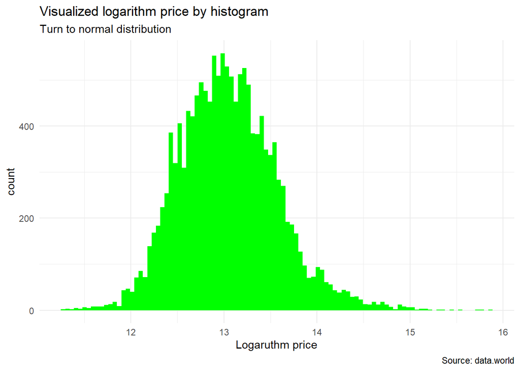

```r
ggplot(df1_log, aes(log_price)) +
  geom_histogram(bins = 100, fill="green") +
  theme_minimal() +
  labs(
    title = "Visualized logarithm price by histogram",
    subtitle = "Turn to normal distribution",
    x = "Logaruthm price",
    caption = "Source: data.world"
  )
```

### 2.2 Train model df1_log and log_price

### 2.2.1 Train

```r
set.seed(42)
model_log <- train(log_price ~ .,
               data = train_data_log[ , -c(1,2,23)], #remove price,id,date
               method = "lm")
```

### 2.2.2 calculate train error

### 2.2.2.1 predict train model_log

```r
p_log_train <- predict(model_log, newdata = train_data_log)
```

### 2.2.2.2 calculate train error from model_log with logarithm price and real price_exp(log)

```r
model_log_r_train <- r_train(train_data_log, p_log_train, model_log)
```

```
## [1] "--Evaulation of TRAIN--"
## [1] "MAE_log_train :  0.186876611630186"
## [1] "MSE_log_train :  0.0592234337771878"
## [1] "RMSE_log_train :  0.243358652562813"
## [1] "MAE_expo_train :  106108.300922603"
## [1] "MSE_expo_train :  32179140733.112"
## [1] "RMSE_expo_train :  179385.45295846"
## [1] "MAE_model :  0.188182348161632"
## [1] "Rsquared_model :  0.783296783181617"
## [1] "RMSE_model :  0.245141773832881"
```

### 2.3 score~predict model(model_log)

```r
p_log_test <- predict(model_log, newdata = test_data_log)
```

### 2.4 Evaluate model(model_log)

```r
model_log_r_test <- r_test(test_data_log, p_log_test, model_log)
```

```
## [1] "--Evaulation of TEST--"
## [1] "MAE_log_test :  0.193446178197938"
## [1] "MSE_log_test :  0.0648345743548279"
## [1] "RMSE_log_test :  0.254626342617624"
## [1] "MAE_expo_test :  119667.914904593"
## [1] "MSE_expo_test :  125501870360.535"
## [1] "RMSE_expo_test :  354262.431483406"
## [1] "MAE_model :  0.188182348161632"
## [1] "Rsquared_model :  0.783296783181617"
## [1] "RMSE_model :  0.245141773832881"
```

## After train model use real price vs logarithm price

## find out the important variable for tuning the new model(model_log_s) for lower error or high accuracy

```
## [1] "variable importance of --> model"
```

```
## lm variable importance
##
##                                                 Overall
## Lattitude                                     100.00000
## `\\`grade of the house\\``                     92.44341
## `\\`waterfront present\\``                     74.02204
## `\\`Built Year\\``                             69.66113
## `\\`living area\\``                            63.87331
## `\\`number of views\\``                        42.45423
## `\\`number of bedrooms\\``                     35.57289
## `\\`condition of the house\\``                 27.05106
## `\\`number of bathrooms\\``                    25.71746
## Longitude                                      16.25183
## `\\`Area of the house(excluding basement)\\``  16.13526
## living_area_renov                              14.38876
## `\\`Renovation Year\\``                        12.85816
## lot_area_renov                                  8.31543
## `\\`Postal Code\\``                             6.56831
## `\\`Number of schools nearby\\``                4.01476
## `\\`number of floors\\``                        3.27998
## `\\`lot area\\``                                0.04566
## `\\`Distance from the airport\\``               0.00000
```

```
## [1] "variable importance of --> model_log"
```

```
## lm variable importance
##
##                                                 Overall
## Lattitude                                     100.00000
## `\\`grade of the house\\``                     63.49513
## `\\`Built Year\\``                             39.30658
## `\\`living area\\``                            30.85679
## `\\`condition of the house\\``                 25.85637
## living_area_renov                              24.40844
## `\\`number of views\\``                        23.01281
## `\\`waterfront present\\``                     19.73784
## `\\`number of bathrooms\\``                    18.30983
## `\\`Postal Code\\``                            18.06680
## `\\`number of floors\\``                       16.05220
## `\\`Renovation Year\\``                        12.04673
## `\\`lot area\\``                                7.21650
## `\\`number of bedrooms\\``                      6.90855
## Longitude                                       4.33343
## `\\`Area of the house(excluding basement)\\``   1.72684
## lot_area_renov                                  1.61028
## `\\`Distance from the airport\\``               0.05296
## `\\`Number of schools nearby\\``                0.00000
```

## 3.1 Subset data from df1 to df1_s and split data

```r
# select varImp from above model for create new model
# subset data to df1_s

df1_s <- df1_log %>%
  select(lat = Lattitude,
         grade = `grade of the house`,
         bld_yr = `Built Year`,
         lv_area = `living area`,
         no_view = `number of views`,
         log_price,Price)

prep_data_s <- split_data(df1_s)
train_data_s <- prep_data_s[[1]]
test_data_s <- prep_data_s[[2]]
```

### 3.2 Train model df1_s and log_price

### 3.2.1 Train

```r
model_log_s <- train(log_price ~ lat + grade + bld_yr + lv_area + no_view,
                   data = train_data_s,
                   method = "lm")
```

### 3.2.2 calculate train error

### 3.2.2.1 predict train model_log_s

```r
p_log_s_train <- predict(model_log_s, newdata = train_data_s)
```

### 3.2.2.2 calculate train error from model_log with logarithm price and real price_exp(log)

```r
## evaluate train model_log_s
model_log_s_r_train <- r_train(train_data_s, p_log_s_train, model_log_s)
```

```
## [1] "--Evaulation of TRAIN--"
## [1] "MAE_log_train :  0.200017418153185"
## [1] "MSE_log_train :  0.0665572466155991"
## [1] "RMSE_log_train :  0.257986911713752"
## [1] "MAE_expo_train :  113400.360686776"
## [1] "MSE_expo_train :  35852543842.0516"
## [1] "RMSE_expo_train :  189347.679790515"
## [1] "MAE_model :  0.200652129732564"
## [1] "Rsquared_model :  0.757465703755575"
## [1] "RMSE_model :  0.258473837659618"
```

### 3.3 score~predict model(model_log_s)

```r
p_log_s_test <- predict(model_log_s, newdata = test_data_s)
```

### 3.4 Evaluate model(model_log_s)

```r
model_log_s_r_test <- r_test(test_data_s, p_log_s_test, model_log_s)
```

```
## [1] "--Evaulation of TEST--"
## [1] "MAE_log_test :  0.205768259455702"
## [1] "MSE_log_test :  0.0725033088154798"
## [1] "RMSE_log_test :  0.269264384602717"
## [1] "MAE_expo_test :  128244.175354101"
## [1] "MSE_expo_test :  196314300729.85"
## [1] "RMSE_expo_test :  443073.696725331"
## [1] "MAE_model :  0.200652129732564"
## [1] "Rsquared_model :  0.757465703755575"
## [1] "RMSE_model :  0.258473837659618"
```

## Now we build model from important variable, calculate error for evaluate model, Next tuning the parameter, train control and resample technic

## 4. The final model

### 4.1 TrainControl repeatCV

```r
set.seed(42)
ctrl <- trainControl(
  method = "repeatedcv",
  number = 5,
  repeats = 5
  #verboseIter = TRUE
)
```

### 4.2 Train final model df1_s and log_price

### 4.2.1 Train

```r
model_lm_final <- train(log_price ~ lat + grade + bld_yr + lv_area + no_view,
                     data = train_data_s,
                     method = "lm",
                     preProcess = c("center", "scale"),
                     trControl = ctrl)
```

### 4.2.2 calculate train error

### 4.2.2.1 predict train model_lm_final

```r
p_lm_final_train <- predict(model_lm_final, newdata = train_data_s)
```

### 4.2.2.2 calculate train error from model_lm_final with logarithm price and real price_exp(log)

```r
model_lm_final_r_train <- r_train(train_data_s, p_lm_final_train, model_lm_final)
```

```
## [1] "--Evaulation of TRAIN--"
## [1] "MAE_log_train :  0.200017418153186"
## [1] "MSE_log_train :  0.0665572466155991"
## [1] "RMSE_log_train :  0.257986911713752"
## [1] "MAE_expo_train :  113400.360686775"
## [1] "MSE_expo_train :  35852543842.0519"
## [1] "RMSE_expo_train :  189347.679790516"
## [1] "MAE_model :  0.200122500185454"
## [1] "Rsquared_model :  0.7591336843618"
## [1] "RMSE_model :  0.258095431757117"
```

### 4.3 score~predict model(model_lm_final)

```r
# test model_lm_final
p_lm_final_test <- predict(model_lm_final, newdata = test_data_s)
```

### 4.4 Evaluate model(model_lm_final)

```r
model_lm_final_r_test <- r_test(test_data_s, p_lm_final_test, model_lm_final)
```

```
## [1] "--Evaulation of TEST--"
## [1] "MAE_log_test :  0.205768259455706"
## [1] "MSE_log_test :  0.0725033088154796"
## [1] "RMSE_log_test :  0.269264384602717"
## [1] "MAE_expo_test :  128244.175354096"
## [1] "MSE_expo_test :  196314300729.781"
## [1] "RMSE_expo_test :  443073.696725252"
## [1] "MAE_model :  0.200122500185454"
## [1] "Rsquared_model :  0.7591336843618"
## [1] "RMSE_model :  0.258095431757117"
```

## Switch method to knn

```r
model_knn_final <- train(log_price ~ lat + grade + bld_yr + lv_area + no_view,
                         data = train_data_s,
                         method = "knn",
                         tuneGrid = data.frame(k=c(5, 7, 13)),
                         preProcess = c("center", "scale"),
                         #preProcess = c("range", "zv", "nzv"),
                         trControl = ctrl)
```

### predict train model_knn_final

```r
p_knn_final_train <- predict(model_knn_final, newdata = train_data_s)
```

### evaluate train model_knn_final

```r
model_knn_final_r_train <- r_train(train_data_s, p_knn_final_train, model_knn_final)
```

```
## [1] "--Evaulation of TRAIN--"
## [1] "MAE_log_train :  0.140665174852055"
## [1] "MSE_log_train :  0.0371433299380822"
## [1] "RMSE_log_train :  0.192726048934964"
## [1] "MAE_expo_train :  81946.2331718462"
## [1] "MSE_expo_train :  25552644789.7944"
## [1] "RMSE_expo_train :  159851.946468582"
## [1] "MAE_model :  0.158835378279188" "MAE_model :  0.155883783285012"
## [3] "MAE_model :  0.153229130059616"
## [1] "Rsquared_model :  0.831110269286084" "Rsquared_model :  0.836307528904411"
## [3] "Rsquared_model :  0.841479039253118"
## [1] "RMSE_model :  0.21640668756905"  "RMSE_model :  0.212880120531821"
## [3] "RMSE_model :  0.209466472413462"
```

### test model_knn_final

```r
p_knn_final_test <- predict(model_knn_final, newdata = test_data_s)
```

### evaluate test model_knn_final

```r
model_knn_final_r_test <- r_test(test_data_s, p_knn_final_test, model_knn_final)
```

```
## [1] "--Evaulation of TEST--"
## [1] "MAE_log_test :  0.158201565950789"
## [1] "MSE_log_test :  0.048164704298204"
## [1] "RMSE_log_test :  0.219464585521683"
## [1] "MAE_expo_test :  93951.1047196991"
## [1] "MSE_expo_test :  44100247868.9621"
## [1] "RMSE_expo_test :  210000.590163366"
## [1] "MAE_model :  0.158835378279188" "MAE_model :  0.155883783285012"
## [3] "MAE_model :  0.153229130059616"
## [1] "Rsquared_model :  0.831110269286084" "Rsquared_model :  0.836307528904411"
## [3] "Rsquared_model :  0.841479039253118"
## [1] "RMSE_model :  0.21640668756905"  "RMSE_model :  0.212880120531821"
## [3] "RMSE_model :  0.209466472413462"
```

## Summary Evaluation

### create vector model, model_log, model_log_s, model_lm_final, model_knn_final

```r
model_name <- c("model",
                "model_log",
                "model_log_s",
                "model_lm_final",
                "model_knn_final")
```

### create vector MAE-train test, MSE-train test, RMSE-train test, Rsquared train

```r
mae_train_log <- c(0,
                   model_log_r_train[[1]],
                   model_log_s_r_train[[1]],
                   model_lm_final_r_train[[1]],
                   model_knn_final_r_train[[1]])

mae_train <- c(model[[4]][[4]],
               model_log_r_train[[4]],
               model_log_s_r_train[[4]],
               model_lm_final_r_train[[4]],
               model_knn_final_r_train[[4]])

mae_test_log <- c(0,
                  model_log_r_test[[1]],
                  model_log_s_r_test[[1]],
                  model_lm_final_r_test[[1]],
                  model_knn_final_r_test[[1]])

mae_test <- c(model[[4]][[4]],
              model_log_r_test[[4]],
              model_log_s_r_test[[4]],
              model_lm_final_r_test[[4]],
              model_knn_final_r_test[[4]])

mse_train_log <- c(0,
                   model_log_r_train[[2]],
                   model_log_s_r_train[[2]],
                   model_lm_final_r_train[[2]],
                   model_knn_final_r_train[[2]])

mse_train <- c(0,
               model_log_r_train[[5]],
               model_log_s_r_train[[5]],
               model_lm_final_r_train[[5]],
               model_knn_final_r_train[[5]])

mse_test_log <- c(0,
                  model_log_r_test[[2]],
                  model_log_s_r_test[[2]],
                  model_lm_final_r_test[[2]],
                  model_knn_final_r_test[[2]])

mse_test <- c(0,
              model_log_r_test[[5]],
              model_log_s_r_test[[5]],
              model_lm_final_r_test[[5]],
              model_knn_final_r_test[[5]])

rmse_train_log <- c(0,
                    model_log_r_train[[3]],
                    model_log_s_r_train[[3]],
                    model_lm_final_r_train[[3]],
                    model_knn_final_r_train[[3]])

rmse_train <- c(model[[4]][[2]],
                model_log_r_train[[6]],
                model_log_s_r_train[[6]],
                model_lm_final_r_train[[6]],
                model_knn_final_r_train[[6]])

rmse_test_log <- c(0,
                   model_log_r_test[[3]],
                   model_log_s_r_test[[3]],
                   model_lm_final_r_test[[3]],
                   model_knn_final_r_test[[3]])

rmse_test <- c(model[[4]][[2]],
               model_log_r_test[[6]],
               model_log_s_r_test[[6]],
               model_lm_final_r_test[[6]],
               model_knn_final_r_test[[6]])

rsquared_model_train <- c(model[[4]][[3]],
                          model_log[[4]][[3]],
                          model_log_s[[4]][[3]],
                          model_lm_final[[4]][[3]],
                          model_knn_final[[4]][[3,3]])
```

### Then create df to compare evaluation

```r
sum_eva <- data.frame(model_name,
                 mae_train_log, mae_train,
                 mae_test_log, mae_test,
                 mse_train_log, mse_train,
                 mse_test_log, mse_test,
                 rmse_train_log, rmse_train,
                 rmse_test_log, rmse_test,
                 rsquared_model_train)
```

### Show compare error evaluation all model

```
##        model_name mae_train_log mae_train mae_test_log mae_test
## 1           model     0.0000000 123219.80    0.0000000 123219.8
## 2       model_log     0.1868766 106108.30    0.1934462 119667.9
## 3     model_log_s     0.2000174 113400.36    0.2057683 128244.2
## 4  model_lm_final     0.2000174 113400.36    0.2057683 128244.2
## 5 model_knn_final     0.1406652  81946.23    0.1582016  93951.1
```

```
##        model_name mse_train_log   mse_train mse_test_log     mse_test
## 1           model    0.00000000           0   0.00000000            0
## 2       model_log    0.05922343 32179140733   0.06483457 125501870361
## 3     model_log_s    0.06655725 35852543842   0.07250331 196314300730
## 4  model_lm_final    0.06655725 35852543842   0.07250331 196314300730
## 5 model_knn_final    0.03714333 25552644790   0.04816470  44100247869
```

```
##        model_name rmse_train_log rmse_train rmse_test_log rmse_test
## 1           model      0.0000000   192549.8     0.0000000  192549.8
## 2       model_log      0.2433587   179385.5     0.2546263  354262.4
## 3     model_log_s      0.2579869   189347.7     0.2692644  443073.7
## 4  model_lm_final      0.2579869   189347.7     0.2692644  443073.7
## 5 model_knn_final      0.1927260   159851.9     0.2194646  210000.6
```

```
##        model_name rsquared_model_train
## 1           model            0.7110370
## 2       model_log            0.7832968
## 3     model_log_s            0.7574657
## 4  model_lm_final            0.7591337
## 5 model_knn_final            0.8414790
```

## CONCLUSION

```
##        model_name mae_train_log mae_train mae_test_log mae_test
## 5 model_knn_final     0.1406652  81946.23    0.1582016  93951.1
```

```
##        model_name mse_train_log   mse_train mse_test_log    mse_test
## 5 model_knn_final    0.03714333 25552644790    0.0481647 44100247869
```

```
##        model_name rmse_train_log rmse_train rmse_test_log rmse_test
## 5 model_knn_final       0.192726   159851.9     0.2194646  210000.6
```

```
##        model_name rsquared_model_train
## 5 model_knn_final             0.841479
```